# INFO 2301 Tutorial - Week 1 - HTML Basics

Last Update: 21 September 2015

## HTML Files

### About

HTML files are basically text files with the extension of `.html` and can be easily created on any operating system. To edit html files, it is encouraged to use a text editor specifically made for editing text files of this sort. There are many editors out there, pick one that you like and stick with it. There is no one recommended editor but it is good to know how to use at least one properly.

Some examples of text editors are as follows:

- [Notepad++](https://notepad-plus-plus.org/)
- [ConTEXT](http://www.contexteditor.org/index.php)
- [Emacs](https://www.gnu.org/software/emacs/)
- [Sublime Text 3](http://www.sublimetext.com/3)

For a more comprehensive list of text editors and their comparison, please refer to the Wikipedia article: [Comparison of text editors](https://en.wikipedia.org/wiki/Comparison_of_text_editors).

### How to create

Since they are simple text files, there are several ways to create them depending on the operating system. For Microsoft Windows, here are a couple:

- Creating a new text file from the right-click context menu of Explorer and then changing the extension from `.txt` to `.html`. In order to be able to see the extension, disable the option `Hide extensions for known file types` in the `View` tab which can be accessed from `Tools > Folder Options` in Windows Explorer. Use the `Alt` button to access the menu in Windows Explorer.
- Opening a text editor and saving a file from there with the `.html` extension.

### Encoding

```html
<h1>This is header 1</h1>
```

## Tags and Elements

### Markup

HTML markup consists of tags and elements. Take the following as an example:

```html
<p>This is a paragraph</p>
```

Here, `<p>` and `</p>` are tags and `This is a paragraph` is the element of those those tags. Specifically, `<p>` is known as the opening tag and `</p>` the closing tag.

**Note:** Not all HTML markup requires closing tags. For example, the `<img>` tag.

### HTML file structure

A basic HTML file structure is as follows[^1]:

```html
<!DOCTYPE HTML>
<html>
    <head>
        <meta http-equiv="Content-Type" content="text/html; charset=UTF-8" />
        <title>Your Website</title>
    </head>

    <body>
    </body>
</html>
```

The structure is made up of two main parts:

- `<head>` contains setup information for the browser & the web page. e.g: the title for the browser window, style definitions, JavaScript code, etc...
- `<body>` contains the actual content to be displayed on the web page.

### Headers

HTML allows for headers up to 6 levels. Headers are used to organize your content similar to how the chapters of a book or sections of a thesis organize content. The top level header is `<h1>` and the lowest level header is `<h6>`. The following is an example of usage:

```html
<!DOCTYPE HTML>
<html>
    <head>
        <meta http-equiv="Content-Type" content="text/html; charset=UTF-8" />
        <title>Your Website</title>
    </head>

    <body>
        <h1>INFO 2301 - Web Programming</h1>
        <p>This class is about teaching HTML and PHP.</p>

        <h2>Week 1</h2>

        <h3>Introduction to HTML and PHP</h3>
        <h3>Basic HTML Markup</h3>
    </body>
</html>
```

Which will give you the following:

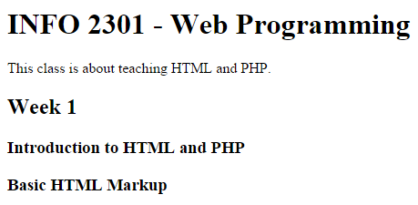

### Lists

There are three kinds of lists that you can use in HTML. Their usage is explained in the following subsections.

#### Ordered Lists `<ol>`

This is to be used when you wish to have a numbered list. It should have several list items `<li>`. A sample list is as follows:

```html
<ol>
    <li>Ordered List Item 1</li>
    <li>Ordered List Item 1</li>
    <li>Ordered List Item 1</li>
</ol>
```

#### Unordered Lists `<ul>`

This is to be used when you wish to have a bullet list. It should have several list items `<li>`. A sample list is as follows:

```html
<ul>
    <li>Unordered List Item 1</li>
    <li>Unordered List Item 1</li>
    <li>Unordered List Item 1</li>
</ul>
```

#### Definition Lists `<dl>`

This list is to be used when you wish to create a definition list much akin to that in a dictionary. Each item in this list will have a term `<dt>` and a definition `<dd>`. A sample list is as follows:

```html
<dl>
    <dt>HTML
    <dd>HyperText Markup Language

    <dt>HTTP
    <dd>HyperText Transfer Protocol
</dl>
```

### Images

Images are a significant part of the web today. The `<img/>` tag is used to link image files to your HTML file and it comes with several attributes. We will discuss the `alt` attribute here and other attributes can be checked over at the [Mozilla Developer Network](https://developer.mozilla.org/en-US/docs/Web/HTML/Element/img#Attributes). Basic syntax for linking images is as follows:

```html
<img src="(your image link with extension)" alt="Your alternative text"/>
```

The `alt` attribute is used to display the text you choose when a browser is unable to load the image on your webiste due to an incorrect link, corrupt image file, incorrect extension or if the end-user uses a text web browser.

**Note:** The `<img>` element does not require a closing tag[^2]. It does however still need a `/` before its closing brace, hence `<img src=""/>`.

### Hyperlinks

Hyperlinks enable us to link text or images to places such as other websites or other webpages on our web server. The syntax for using them for text is as follows:

```html
<a href="(your link here)">Your Link Text</a>
```

If you wish to add links to images, then use the following syntax:

```html
<a href="(your link here)"><img src="(your image link here)"/></a>
```

#### Links within documents

The lecture slides show how to do this using the `name` attribute of the `<a>` tag but this has become obsolete since HTML5[^3]. This has also been explained in a StackOverflow [question](https://stackoverflow.com/questions/484719/html-anchors-with-name-or-id). The recommended way to do this now is to utitlize the `id` attribute with `<a>` or header tags or any other text related tags. An example is as follows:

```html
Go to <a href="#Section_1">Section 1</a>.

<h2 id="Section_1">Section 1</h2>
```

### Tables

Tables in HTML are aking to their counterparts in print and are used to display tabular data. The simplest syntax for a table is as follows:

```html
<table>
  <tr>
    <td>Khalid</td>
    <td>Hussain</td>
  </tr>
  <tr>
    <td>Sajid</td>
    <td>Hussain</td>
  </tr>
</table>
```

A more structured table can be achieved as follows[^4]:

```html
<table>
  <thead>
    <tr>
      <th>Header content 1</th>
      <th>Header content 2</th>
    </tr>
  </thead>
  <tfoot>
    <tr>
      <td>Footer content 1</td>
      <td>Footer content 2</td>
    </tr>
  </tfoot>
  <tbody>
    <tr>
      <td>Body content 1</td>
      <td>Body content 2</td>
    </tr>
  </tbody>
</table>
```

More information about tables can be obtained from the [Mozilla Developer Network](https://developer.mozilla.org/en-US/docs/Web/HTML/Element/table).

[^1]: https://css-tricks.com/snippets/html/html5-page-structure/
[^2]: https://developer.mozilla.org/en-US/docs/Web/HTML/Element/img#Summary
[^3]: http://www.w3.org/TR/html5/text-level-semantics.html#the-a-element
[^4]: https://developer.mozilla.org/en-US/docs/Web/HTML/Element/table#More_Examples